# IBM LAB 7.6

Ahmed Marey

2023-04-25

# 1 Model Evaluation and Refinement with Tidymodels

We first have to load the needed libraries

```r
library(tidyverse)
library(tidymodels)
```

Let’s load the needed data with the “*download.file()*” function

```r
url <- "https://dax-cdn.cdn.appdomain.cloud/dax-airline/1.0.1/lax_to_jfk.tar.gz"

download.file(url, destfile = "lax_to_jfk.tar.gz")

untar("lax_to_jfk.tar.gz", tar = "internal")
airline_data <- read_csv("lax_to_jfk/lax_to_jfk.csv")
glimpse(airline_data)
```

```
## Rows: 2,855
## Columns: 21
## $ Month             <dbl> 3, 11, 8, 4, 11, 4, 12, 12, 2, 3, 10, 8, 6, 2, 8, 3,…
## $ DayOfWeek         <dbl> 5, 4, 5, 7, 3, 1, 1, 3, 4, 4, 4, 5, 4, 3, 7, 6, 4, 4…
## $ FlightDate        <date> 2003-03-28, 2018-11-29, 2015-08-28, 2003-04-20, 200…
## $ Reporting_Airline <chr> "UA", "AS", "UA", "DL", "UA", "UA", "VX", "HP", "UA"…
## $ Origin            <chr> "LAX", "LAX", "LAX", "LAX", "LAX", "LAX", "LAX", "LA…
## $ Dest              <chr> "JFK", "JFK", "JFK", "JFK", "JFK", "JFK", "JFK", "JF…
## $ CRSDepTime        <chr> "2210", "1045", "0805", "2205", "0840", "1450", "104…
## $ CRSArrTime        <chr> "0615", "1912", "1634", "0619", "1653", "2308", "190…
## $ DepTime           <chr> "2209", "1049", "0757", "2212", "0836", "1452", "103…
## $ ArrTime           <chr> "0617", "1851", "1620", "0616", "1640", "2248", "190…
## $ ArrDelay          <dbl> 2, -21, -14, -3, -13, -20, 1, -40, 25, 7, 5, 34, 21,…
## $ ArrDelayMinutes   <dbl> 2, 0, 0, 0, 0, 0, 1, 0, 25, 7, 5, 34, 21, 0, 14, 682…
## $ CarrierDelay      <dbl> NA, NA, NA, NA, NA, NA, NA, NA, NA, NA, NA, 11, 0, N…
## $ WeatherDelay      <dbl> NA, NA, NA, NA, NA, NA, NA, NA, NA, NA, NA, 0, 0, NA…
## $ NASDelay          <dbl> NA, NA, NA, NA, NA, NA, NA, NA, NA, NA, NA, 23, 21, …
## $ SecurityDelay     <dbl> NA, NA, NA, NA, NA, NA, NA, NA, NA, NA, NA, 0, 0, NA…
## $ LateAircraftDelay <dbl> NA, NA, NA, NA, NA, NA, NA, NA, NA, NA, NA, 0, 0, NA…
## $ DepDelay          <dbl> -1, 4, -8, 7, -4, 2, -2, -2, 2, 15, 2, 21, -8, -2, -…
## $ DepDelayMinutes   <dbl> 0, 4, 0, 7, 0, 2, 0, 0, 2, 15, 2, 21, 0, 0, 0, 395, …
## $ DivDistance       <lgl> NA, NA, NA, NA, NA, NA, NA, NA, NA, NA, NA, NA, NA, …
## $ DivArrDelay       <lgl> NA, NA, NA, NA, NA, NA, NA, NA, NA, NA, NA, NA, NA, …
```

As we can see we have some data with the wrong format, such as the DivDistance and the DivArrDelay, we can fix it using “*col_types()*” in the “*read_csv()*” argument

```r
airline_data <- read_csv("lax_to_jfk/lax_to_jfk.csv",
                         col_types = cols(
                           DivDistance = col_number(),
                           DivArrDelay = col_number()
                         ))
```

```r
glimpse(airline_data)
```

```
## Rows: 2,855
## Columns: 21
## $ Month             <dbl> 3, 11, 8, 4, 11, 4, 12, 12, 2, 3, 10, 8, 6, 2, 8, 3,…
## $ DayOfWeek         <dbl> 5, 4, 5, 7, 3, 1, 1, 3, 4, 4, 4, 5, 4, 3, 7, 6, 4, 4…
## $ FlightDate        <date> 2003-03-28, 2018-11-29, 2015-08-28, 2003-04-20, 200…
## $ Reporting_Airline <chr> "UA", "AS", "UA", "DL", "UA", "UA", "VX", "HP", "UA"…
## $ Origin            <chr> "LAX", "LAX", "LAX", "LAX", "LAX", "LAX", "LAX", "LA…
## $ Dest              <chr> "JFK", "JFK", "JFK", "JFK", "JFK", "JFK", "JFK", "JF…
## $ CRSDepTime        <chr> "2210", "1045", "0805", "2205", "0840", "1450", "104…
## $ CRSArrTime        <chr> "0615", "1912", "1634", "0619", "1653", "2308", "190…
## $ DepTime           <chr> "2209", "1049", "0757", "2212", "0836", "1452", "103…
## $ ArrTime           <chr> "0617", "1851", "1620", "0616", "1640", "2248", "190…
## $ ArrDelay          <dbl> 2, -21, -14, -3, -13, -20, 1, -40, 25, 7, 5, 34, 21,…
## $ ArrDelayMinutes   <dbl> 2, 0, 0, 0, 0, 0, 1, 0, 25, 7, 5, 34, 21, 0, 14, 682…
## $ CarrierDelay      <dbl> NA, NA, NA, NA, NA, NA, NA, NA, NA, NA, NA, 11, 0, N…
## $ WeatherDelay      <dbl> NA, NA, NA, NA, NA, NA, NA, NA, NA, NA, NA, 0, 0, NA…
## $ NASDelay          <dbl> NA, NA, NA, NA, NA, NA, NA, NA, NA, NA, NA, 23, 21, …
## $ SecurityDelay     <dbl> NA, NA, NA, NA, NA, NA, NA, NA, NA, NA, NA, 0, 0, NA…
## $ LateAircraftDelay <dbl> NA, NA, NA, NA, NA, NA, NA, NA, NA, NA, NA, 0, 0, NA…
## $ DepDelay          <dbl> -1, 4, -8, 7, -4, 2, -2, -2, 2, 15, 2, 21, -8, -2, -…
## $ DepDelayMinutes   <dbl> 0, 4, 0, 7, 0, 2, 0, 0, 2, 15, 2, 21, 0, 0, 0, 395, …
## $ DivDistance       <dbl> NA, NA, NA, NA, NA, NA, NA, NA, NA, NA, NA, NA, NA, …
## $ DivArrDelay       <dbl> NA, NA, NA, NA, NA, NA, NA, NA, NA, NA, NA, NA, NA, …
```

# 2 MODEL EVALUATION

## 2.1 TRAINING AND TESTING DATA

We now want to perform a model evaluation by training our predictor machine on the data from the airline table, by splitting it in two sets, the training data, on which we will train it, and the testing data, where we are going to see the prediction assumed by the machine and the actual delays shown in the table, by doing so we will be able to define how close our assumption are from the actual values.

As we can see in the data shown above, some of the data are shown as NA’s, but in that particular case those values are not “missing”, they just mean that the delays was equal to 0. That said, we can change them into actual 0’s.

```r
airline_data <- airline_data |> replace_na(list(
  CarrierDelay = 0,
  WeatherDelay = 0,
  NASDelay = 0,
  SecurityDelay = 0,
  LateAircraftDelay = 0
))
```

```r
head(airline_data)
```

```
## # A tibble: 6 × 21
##   Month DayOfW…¹ FlightDate Repor…² Origin Dest  CRSDe…³ CRSAr…⁴ DepTime ArrTime
##   <dbl>    <dbl> <date>     <chr>   <chr>  <chr> <chr>   <chr>   <chr>   <chr>
## 1     3        5 2003-03-28 UA      LAX    JFK   2210    0615    2209    0617
## 2    11        4 2018-11-29 AS      LAX    JFK   1045    1912    1049    1851
## 3     8        5 2015-08-28 UA      LAX    JFK   0805    1634    0757    1620
## 4     4        7 2003-04-20 DL      LAX    JFK   2205    0619    2212    0616
## 5    11        3 2005-11-30 UA      LAX    JFK   0840    1653    0836    1640
## 6     4        1 1992-04-06 UA      LAX    JFK   1450    2308    1452    2248
## # … with 11 more variables: ArrDelay <dbl>, ArrDelayMinutes <dbl>,
## #   CarrierDelay <dbl>, WeatherDelay <dbl>, NASDelay <dbl>,
## #   SecurityDelay <dbl>, LateAircraftDelay <dbl>, DepDelay <dbl>,
## #   DepDelayMinutes <dbl>, DivDistance <dbl>, DivArrDelay <dbl>, and
## #   abbreviated variable names ¹DayOfWeek, ²Reporting_Airline, ³CRSDepTime,
## #   ⁴CRSArrTime
```

From that data we can “*select()*” the only needed columns to better analyze it.

```r
flight_delays <- airline_data |>
  select(c(ArrDelayMinutes, DepDelayMinutes, CarrierDelay, WeatherDelay, NASDelay, SecurityDelay, LateAircraftDelay, DayOfWeek, Month))
```

```r
head(flight_delays)
```

```
## # A tibble: 6 × 9
##   ArrDelayMinutes DepDel…¹ Carri…² Weath…³ NASDe…⁴ Secur…⁵ LateA…⁶ DayOf…⁷ Month
##             <dbl>    <dbl>   <dbl>   <dbl>   <dbl>   <dbl>   <dbl>   <dbl> <dbl>
## 1               2        0       0       0       0       0       0       5     3
## 2               0        4       0       0       0       0       0       4    11
## 3               0        0       0       0       0       0       0       5     8
## 4               0        7       0       0       0       0       0       7     4
## 5               0        0       0       0       0       0       0       3    11
## 6               0        2       0       0       0       0       0       1     4
## # … with abbreviated variable names ¹DepDelayMinutes, ²CarrierDelay,
## #   ³WeatherDelay, ⁴NASDelay, ⁵SecurityDelay, ⁶LateAircraftDelay, ⁷DayOfWeek
```

Now that we set all the parameters, we can split the table into two with a random seed “*set.seed()*” so every time we will use the same number we will achieve the same split. Therefor we can use “*initial_split()*” to divide it.

```r
set.seed(1234)

flight_split <- initial_split(flight_delays)

train_set <- training(flight_split)

test_set <- testing(flight_split)
```

```r
head(test_set)
```

```
## # A tibble: 6 × 9
##   ArrDelayMinutes DepDel…¹ Carri…² Weath…³ NASDe…⁴ Secur…⁵ LateA…⁶ DayOf…⁷ Month
##             <dbl>    <dbl>   <dbl>   <dbl>   <dbl>   <dbl>   <dbl>   <dbl> <dbl>
## 1               2        0       0       0       0       0       0       5     3
## 2               0        0       0       0       0       0       0       5     8
## 3               0        0       0       0       0       0       0       3    12
## 4              34       21      11       0      23       0       0       5     8
## 5               0        0       0       0       0       0       0       3     2
## 6               0        0       0       0       0       0       0       4     7
## # … with abbreviated variable names ¹DepDelayMinutes, ²CarrierDelay,
## #   ³WeatherDelay, ⁴NASDelay, ⁵SecurityDelay, ⁶LateAircraftDelay, ⁷DayOfWeek
```

```r
head(train_set)
```

```
## # A tibble: 6 × 9
##   ArrDelayMinutes DepDel…¹ Carri…² Weath…³ NASDe…⁴ Secur…⁵ LateA…⁶ DayOf…⁷ Month
##             <dbl>    <dbl>   <dbl>   <dbl>   <dbl>   <dbl>   <dbl>   <dbl> <dbl>
## 1               8        0       0       0       0       0       0       6     1
## 2               9        0       0       0       0       0       0       2     9
## 3              27        0       0       0       0       0       0       3     9
## 4               9        0       0       0       0       0       0       4    10
## 5               9       12       0       0       0       0       0       6     9
## 6               0        1       0       0       0       0       0       5     7
## # … with abbreviated variable names ¹DepDelayMinutes, ²CarrierDelay,
## #   ³WeatherDelay, ⁴NASDelay, ⁵SecurityDelay, ⁶LateAircraftDelay, ⁷DayOfWeek
```

If you want to operate in a more specific relation, you can add in the “*initial_split*” argument, the voice “*prop()*” to set a percentage in between the two data sets.

### 2.1.1 EXERCISE TRAINING AND TESTING

Perform a split with a 0.80 relation, generating a flight_split2 data.

**Click here to view the solution**

```r
flight_split2 <- initial_split(flight_delays, prop = 0.8)

train_set2 <- training(flight_split2)

test_set2 <- testing(flight_split2)
```

```r
head(train_set2)
```

```
## # A tibble: 6 × 9
##   ArrDelayMinutes DepDel…¹ Carri…² Weath…³ NASDe…⁴ Secur…⁵ LateA…⁶ DayOf…⁷ Month
##             <dbl>    <dbl>   <dbl>   <dbl>   <dbl>   <dbl>   <dbl>   <dbl> <dbl>
## 1               0        0       0       0       0       0       0       3    12
## 2               0        0       0       0       0       0       0       5     7
## 3              25       10       0       0      21       0       4       5     8
## 4               0        0       0       0       0       0       0       3     7
## 5              20        0       0       0       0       0       0       5     5
## 6               0        0       0       0       0       0       0       2     8
## # … with abbreviated variable names ¹DepDelayMinutes, ²CarrierDelay,
## #   ³WeatherDelay, ⁴NASDelay, ⁵SecurityDelay, ⁶LateAircraftDelay, ⁷DayOfWeek
```

```r
head(test_set2)
```

```
## # A tibble: 6 × 9
##   ArrDelayMinutes DepDel…¹ Carri…² Weath…³ NASDe…⁴ Secur…⁵ LateA…⁶ DayOf…⁷ Month
##             <dbl>    <dbl>   <dbl>   <dbl>   <dbl>   <dbl>   <dbl>   <dbl> <dbl>
## 1              34       21      11       0      23       0       0       5     8
## 2              12        3       0       0       0       0       0       3     8
## 3               0       12       0       0       0       0       0       2     1
## 4               5        0       0       0       0       0       0       4     5
## 5              28       28       0       0      28       0       0       3    10
## 6               0        0       0       0       0       0       0       2     4
## # … with abbreviated variable names ¹DepDelayMinutes, ²CarrierDelay,
## #   ³WeatherDelay, ⁴NASDelay, ⁵SecurityDelay, ⁶LateAircraftDelay, ⁷DayOfWeek
```

## 2.2 TRAINING A MODEL

The next step to perform is the generation of a **Linear Regression** by using “*linear_reg()*” with the argument “*set_engine*” that specifies the package used to generate the regression.

```r
reg_model <- linear_reg() |>
  set_engine(engine = "lm")
```

Now we can use that model on the data that we have been preparing. We can use “*fit()*” to associate it with our model.

```r
train_fit <- reg_model |>
  fit(ArrDelayMinutes ~ DepDelayMinutes, data = train_set)

train_fit
```

```
## parsnip model object
##
##
## Call:
## stats::lm(formula = ArrDelayMinutes ~ DepDelayMinutes, data = data)
##
## Coefficients:
##     (Intercept)  DepDelayMinutes
##          2.2660           0.9629
```

To see some of the predicted results, we can use “*predict()*” that will print one column named “.pred” with the values in it.

```r
train_result <- train_fit |>
  predict(new_data = train_set) |>
  mutate(truth = train_set$ArrDelayMinutes)

head(train_result)
```

```
## # A tibble: 6 × 2
##   .pred truth
##   <dbl> <dbl>
## 1  2.27     8
## 2  2.27     9
## 3  2.27    27
## 4  2.27     9
## 5 13.8      9
## 6  3.23     0
```

### 2.2.1 EXERCISE TRAINING A MODEL

Now evaluate the accuracy of the machine on the test set using the train_ft model, thereafter print a two columns table that shows the truth values and the predicted values.

**Click here to see the solution**

```r
test_result <- train_fit |>
  predict(new_data = test_set) |>
  mutate(truth = test_set$ArrDelayMinutes)

head(test_result)
```

```
## # A tibble: 6 × 2
##   .pred truth
##   <dbl> <dbl>
## 1  2.27     2
## 2  2.27     0
## 3  2.27     0
## 4 22.5     34
## 5  2.27     0
## 6  2.27     0
```

## 2.3 EVALUATING THE MODEL

In the previous model we have seen how to calculate the valuation criteria, such as “**RMSE**” and “**R”**” with functions like “*mean()*” and “*sqrt()*”, but with tidyverse we can easily use other functions, like “*rmse()*”. Let’s evalaute the results.

```r
rmse(train_result, truth = truth,
     estimate = .pred)
```

```
## # A tibble: 1 × 3
##   .metric .estimator .estimate
##   <chr>   <chr>          <dbl>
## 1 rmse    standard        14.4
```

```r
rmse(test_result, truth = truth,
     estimate = .pred)
```

```
## # A tibble: 1 × 3
##   .metric .estimator .estimate
##   <chr>   <chr>          <dbl>
## 1 rmse    standard        13.4
```

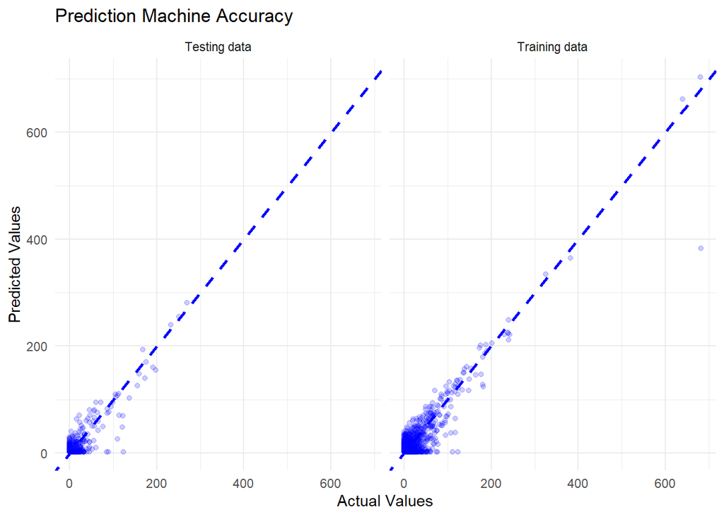

```r
test_result |>
  mutate(origin = "Testing data") |>
  bind_rows(train_result |> mutate(origin = "Training data")) |>
  ggplot(aes(truth, .pred)) +
  geom_point(color = "blue", alpha = 0.2) +
  geom_abline(lty = 2, color = "blue", size = 1) +
  facet_wrap(~origin) +
  labs(x = "Actual Values", y = "Predicted Values") +
  ggtitle("Prediction Machine Accuracy") +
  theme_minimal()
```

### 2.3.1 EXERCISE EVALUATING A MODEL

**Click here to see the solution**

```r
train_fit2 <- reg_model |>
  fit(ArrDelayMinutes ~ DepDelayMinutes, data = test_set2)

train_fit2
```

```
## parsnip model object
##
##
## Call:
## stats::lm(formula = ArrDelayMinutes ~ DepDelayMinutes, data = data)
##
## Coefficients:
##     (Intercept)  DepDelayMinutes
##          2.7863           0.9171
```

```r
train_result2 <- train_fit2 |>
  predict(new_data = train_set2) |>
  mutate(truth = train_set2$ArrDelayMinutes)

head(train_result2)
```

```
## # A tibble: 6 × 2
##   .pred truth
##   <dbl> <dbl>
## 1  2.79     0
## 2  2.79     0
## 3 12.0     25
## 4  2.79     0
## 5  2.79    20
## 6  2.79     0
```

```r
test_result2 <- train_fit2 |>
  predict(new_data = test_set2) |>
  mutate(truth = test_set2$ArrDelayMinutes)

head(test_result2)
```

```
## # A tibble: 6 × 2
##   .pred truth
##   <dbl> <dbl>
## 1 22.0     34
## 2  5.54    12
## 3 13.8      0
## 4  2.79     5
## 5 28.5     28
## 6  2.79     0
```

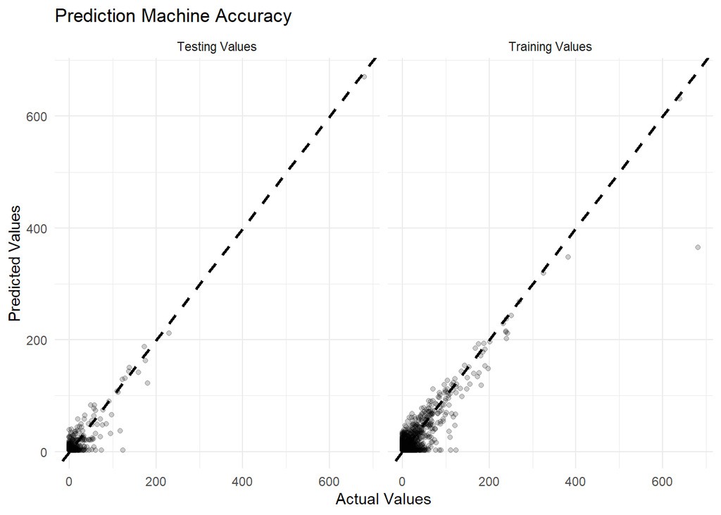

```r
test_result2 |>
  mutate(origin2 = "Testing Values") |>
  bind_rows( train_result2 |> mutate(origin2 = "Training Values")) |>
  ggplot(aes(truth, .pred)) +
  geom_abline(lty = 2, color = "black", size = 1) +
  geom_point(color = "black", alpha = 0.2) +
  facet_wrap(~origin2) +
  labs(x = "Actual Values", y = "Predicted Values") +
  ggtitle("Prediction Machine Accuracy") +
  theme_minimal()
```

## 2.4 CROSS VALIDATION

One of the most common “out-of-sample” evaluation techniques is cross validation. Cross validation is an effective use of data because each observation is used for both training and testing. In cross validation, 1, The dataset is split into k-equal groups; each group is referred to as a fold, 2, k - 1 of the folds are used to train a model, and the remaining fold is used to test with an evaluation metric, 3, This is repeated until each of the k groups is used as the test set, 4, After all folds are used, there are k evaluation metric results. They are averaged to get an estimate of out-of-sample error. To perform cross validation, you can use “*vfold_cv()*”.

```r
set.seed(1234)

data_folds <- vfold_cv(train_set, v = 10)

folds_results <- fit_resamples(reg_model,
                               ArrDelayMinutes ~ DepDelayMinutes,
                               resample = data_folds)
```

To see the result use “*collect_metrics()*”

```r
folds_results |> collect_metrics()
```

```
## # A tibble: 2 × 6
##   .metric .estimator   mean     n std_err .config
##   <chr>   <chr>       <dbl> <int>   <dbl> <chr>
## 1 rmse    standard   14.1      10  1.23   Preprocessor1_Model1
## 2 rsq     standard    0.823    10  0.0343 Preprocessor1_Model1
```

# 3 REGULARIZATION

Regularization is a way to handle the problem of over fitting. It is a technique you can use to reduce the complexity of the model by adding a penalty on the different parameters of the model. After it is applied, the model will be less likely to fit the noise of the training data and will improve the generalization abilities of the model. We have different types of REGULARIZATION.

## 3.1 RIDGE REGULARIZATION - L2

First we must create the “Recipe” of data with “*recipe()*”

```r
ridge_recipe <-
  recipe(ArrDelayMinutes ~ ., data = train_set)
```

Now we have to specify the model using “*linear_reg()*” with the arguments “*penalty*” and “*mixture*”. For this chapter the mixture has to be 0, that indicates the type of regularization we are performing.

```r
ridge_engine <- linear_reg(penalty = 0.1, mixture = 0) |>
  set_engine("glmnet")
```

To facilitate the work when performing the analysis, we can create a workflow as shown below.

```r
ridge_workflow <- workflow() |>
  add_recipe(ridge_recipe)
```

Now that everything is set, we can calculate it.

```r
ridge_fit <- ridge_workflow |>
  add_model(ridge_engine) |>
  fit(data = train_set)
```

The results can be shown like that.

```r
ridge_fit |>
  pull_workflow_fit() |>
  tidy()
```

```
## # A tibble: 9 × 3
##   term              estimate penalty
##   <chr>                <dbl>   <dbl>
## 1 (Intercept)         2.92       0.1
## 2 DepDelayMinutes     0.716      0.1
## 3 CarrierDelay        0.207      0.1
## 4 WeatherDelay        0.243      0.1
## 5 NASDelay            0.496      0.1
## 6 SecurityDelay       0.302      0.1
## 7 LateAircraftDelay   0.207      0.1
## 8 DayOfWeek           0.0900     0.1
## 9 Month              -0.116      0.1
```

### 3.1.1 EXERCISE RIDGE REGULARIZATION

List the necessary steps to perform a **Ridge Regularization**.

**Click here to see the solution**

RECIPE ENGINE WORKFLOW FIT RESULTS

Execute the necessary steps to perform a **Ridge Regularization**.

**Click here to see the solution**

```r
ridge_recipe <- recipe(
  ArrDelayMinutes ~ ., data = train_set
)
```

```r
ridge_engine <- linear_reg(penalty = 0.1, mixture = 0) |>
  set_engine("glmnet")
```

```r
ridge_workflow <- workflow() |>
  add_recipe(ridge_recipe)
```

```r
ridge_fit <- ridge_workflow |>
  add_model(ridge_engine) |>
  fit(data = train_set)
```

```r
ridge_fit |>
  pull_workflow_fit() |>
  tidy()
```

```
## # A tibble: 9 × 3
##   term              estimate penalty
##   <chr>                <dbl>   <dbl>
## 1 (Intercept)         2.92       0.1
## 2 DepDelayMinutes     0.716      0.1
## 3 CarrierDelay        0.207      0.1
## 4 WeatherDelay        0.243      0.1
## 5 NASDelay            0.496      0.1
## 6 SecurityDelay       0.302      0.1
## 7 LateAircraftDelay   0.207      0.1
## 8 DayOfWeek           0.0900     0.1
## 9 Month              -0.116      0.1
```

## 3.2 LASSO REGULARIZATION - L1

Same is applied to the **Lasso** regularization, with the only difference in the formula regarding the “*mixture*” argument in the “*linear_reg()*” formula. Said so, perform a Lasso regularization on the same variables.

RECIPE - ENGINE - WORKFLOW - FIT - RESULTS

**Click here to see the solution**

```r
lasso_recipe <- recipe(
  ArrDelayMinutes ~ ., data = train_set
)

lasso_recipe
```

```
## ── Recipe ──────────────────────────────────────────────────────────────────────
```

```
## ── Inputs
```

```
## Number of variables by role
```

```
## outcome:   1
## predictor: 8
```

```r
lasso_engine <- linear_reg( penalty = 0.1, mixture = 1) |>
  set_engine("glmnet")

lasso_engine
```

```
## Linear Regression Model Specification (regression)
##
## Main Arguments:
##   penalty = 0.1
##   mixture = 1
##
## Computational engine: glmnet
```

```r
lasso_workflow <- workflow() |>
  add_recipe(lasso_recipe)

lasso_workflow
```

```
## ══ Workflow ════════════════════════════════════════════════════════════════════
## Preprocessor: Recipe
## Model: None
##
## ── Preprocessor ────────────────────────────────────────────────────────────────
## 0 Recipe Steps
```

```r
lasso_fit <- lasso_workflow |>
  add_model(lasso_engine) |>
  fit(data = train_set)

lasso_fit
```

```
## ══ Workflow [trained] ══════════════════════════════════════════════════════════
## Preprocessor: Recipe
## Model: linear_reg()
##
## ── Preprocessor ────────────────────────────────────────────────────────────────
## 0 Recipe Steps
##
## ── Model ───────────────────────────────────────────────────────────────────────
##
## Call:  glmnet::glmnet(x = maybe_matrix(x), y = y, family = "gaussian",      alpha = ~1)
##
##    Df  %Dev Lambda
## 1   0  0.00 35.500
## 2   1 14.58 32.350
## 3   1 26.69 29.470
```

[output cut: 46 more lines]

```r
lasso_fit |>
  pull_workflow_fit() |>
  tidy()
```

```
## # A tibble: 9 × 3
##   term              estimate penalty
##   <chr>                <dbl>   <dbl>
## 1 (Intercept)         1.80       0.1
## 2 DepDelayMinutes     0.904      0.1
## 3 CarrierDelay        0.0254     0.1
## 4 WeatherDelay        0.0560     0.1
## 5 NASDelay            0.435      0.1
## 6 SecurityDelay       0.0551     0.1
## 7 LateAircraftDelay   0.0240     0.1
## 8 DayOfWeek           0          0.1
## 9 Month              -0.0582     0.1
```

## 3.3 ELASTIC NET REGULARIZATION

Like mentioned before, mixture is the proportion of L1 penalty used. Since elastic net uses a combination of L1 and L2 regularization, then when mixture is set to a value between 0 and 1 (not including 0 and 1) then it is considered elastic net regularization.

```r
elastic_recipe <- recipe(
  ArrDelayMinutes ~ ., data = train_set
)
```

```r
elastic_engine <- linear_reg(penalty = 0.1, mixture = 0.3) |>
  set_engine("glmnet")
```

```r
elastic_workflow <- workflow() |>
  add_recipe(elastic_recipe)
```

```r
elastic_fit <- elastic_workflow |>
  add_model(elastic_engine) |>
  fit(data = train_set)
```

```r
elastic_fit |>
  pull_workflow_fit() |>
  tidy()
```

```
## # A tibble: 9 × 3
##   term              estimate penalty
##   <chr>                <dbl>   <dbl>
## 1 (Intercept)         1.94       0.1
## 2 DepDelayMinutes     0.890      0.1
## 3 CarrierDelay        0.0414     0.1
## 4 WeatherDelay        0.0818     0.1
## 5 NASDelay            0.443      0.1
## 6 SecurityDelay       0.114      0.1
## 7 LateAircraftDelay   0.0405     0.1
## 8 DayOfWeek           0          0.1
## 9 Month              -0.0722     0.1
```

**Lasso (L1):** Pros: Lasso is primarily used for variable selection, that is, reducing the number of variables/features used in a model by shrinking the coefficients to zero. You would use this if you have many variables and think just a select few would will be useful in a final model. Cons: The downside of Lasso is that its variable selection is unstable, as in, for correlated variables it will arbitrarily select one. Additionally, if the number of data point (n) is less than the number of features (p), then Lasso can select at most n of the features.

**Ridge (L2):** Pros: If you don’t want to reduce the number of variables, you can use this. Ridge also works well when there is multicollinearity in the features because it reduces the variance while increasing bias. Cons: Will not reduce the number of variables if that is your goal. Also, the bias in the model may be high.

**Elastic net (L1/L2):** Pros: Elastic net combines the benefits of Lasso and Ridge. It solves some of the issues that Lasso has when doing variable selection because it works well when the variables are highly correlated and it can work when the number of variables is greater than the number of samples. Cons: May be computationally more expensive than Lasso or Ridge because it computes both L1 and L2 penalties.

# 4 GRID RESEARCH

The goal of grid search is to find the values of the hyperparameters that results in the best model. This is known as tuning hyperparameters. Hyperparameters are parameters that are not derived from training the model. For example: 𝜆 (or lambda) (Is the value of “*penalty*” in the “*linear_reg()*” argument) in ridge/lasso is a hyperparameter. First we define the the Model, in that case a lasso model.

```r
tune_recipe <- recipe(
  ArrDelayMinutes ~ ., data = train_set
)
```

```r
tune_engine <- linear_reg(penalty = tune(), mixture = 1) |>
  set_engine("glmnet")
```

```r
tune_workflow <- workflow() |>
  add_recipe(tune_recipe)
```

Now we want to define the cross validation to re sample the data thanks to “*vfold_cv()*”.

```r
tune_data_folds <- vfold_cv(train_set)
```

Using “*grid_regular()*” we can set un the grid, with an argument “*levels*” that specifies the number of values to use in “*penalty()*”.

```r
tune_regular_grid <- grid_regular(levels = 50, penalty(range = c(-3, 0.3)))
```

Using “*tune_grid()*” we can include those values that we just set.

```r
tune_grid_values <- tune_grid(
  tune_workflow |> add_model(tune_engine), resample = tune_data_folds, grid = tune_regular_grid
)
```

To view the best results, we can print the value with “*show_best()*”.

```r
show_best(tune_grid_values, metric = "rmse")
```

```
## # A tibble: 5 × 7
##   penalty .metric .estimator  mean     n std_err .config
##     <dbl> <chr>   <chr>      <dbl> <int>   <dbl> <chr>
## 1   1.25  rmse    standard    12.7    10    1.71 Preprocessor1_Model47
## 2   1.07  rmse    standard    12.7    10    1.73 Preprocessor1_Model46
## 3   0.919 rmse    standard    12.7    10    1.75 Preprocessor1_Model45
## 4   1.46  rmse    standard    12.7    10    1.69 Preprocessor1_Model48
## 5   0.787 rmse    standard    12.7    10    1.76 Preprocessor1_Model44
```

### 4.0.1 EXERCISE GRID RESEARCH

Perform the same analysis on a Ridge Regression.

**Click here to see the solution**

```r
tune_recipe3 <- recipe(
  ArrDelayMinutes ~ ., data = train_set
)
```

```r
tune_engine3 <- linear_reg(penalty = tune(), mixture = 0) |>
  set_engine("glmnet")
```

```r
tune_workflow3 <- workflow() |>
  add_recipe(tune_recipe3)
```

```r
tune_folds3 <- vfold_cv(data = train_set)
```

```r
tune_regular_grid3 <- grid_regular(levels = 50, penalty(range = c(-3, 0.3)))
```

```r
tune_value3 <- tune_grid(
  tune_workflow3 |> add_model(tune_engine3), resample = tune_folds3, grid = tune_regular_grid3
)
```

```r
show_best(tune_value3, metric = "rmse")
```

```
## # A tibble: 5 × 7
##   penalty .metric .estimator  mean     n std_err .config
##     <dbl> <chr>   <chr>      <dbl> <int>   <dbl> <chr>
## 1 0.001   rmse    standard    12.7    10    2.15 Preprocessor1_Model01
## 2 0.00117 rmse    standard    12.7    10    2.15 Preprocessor1_Model02
## 3 0.00136 rmse    standard    12.7    10    2.15 Preprocessor1_Model03
## 4 0.00159 rmse    standard    12.7    10    2.15 Preprocessor1_Model04
## 5 0.00186 rmse    standard    12.7    10    2.15 Preprocessor1_Model05
```